# Assessment1_Part3

Kris Chavez (s4591950)

2022-05-18

# 1 Part 3: Topic modeling and visualization

## 1.1 Preprocess text from your dataset to tidy text and convert it to DocumentTermMatrix

```r
# Text
# climate_data <- tm_map(climate_corpus, content_transformer(tolower)) # Convert the text to lower case
climate_data$text <- removeNumbers(climate_data$text) # Removes numbers
climate_data$text <- removeWords(climate_data$text, stopwords("english")) # Removes English common stop words
climate_data$text <- removePunctuation(climate_data$text) # Removes punctuation
climate_data$text <- stripWhitespace(climate_data$text) # Eliminate extra white spaces

climate_data$text <- str_replace_all(climate_data$text,"@\\w+", "" )
climate_data$text <- str_replace_all(climate_data$text,"https://.*\\w+", "")
climate_data$text <- str_remove_all(climate_data$text,"[[:punct:]]")

# Unnest token
# Separating the each word from TEXT column
data_unnest <- climate_data %>%
  select(text) %>%
  unnest_tokens(word, text) %>%
  anti_join(get_stopwords())
# Create a corpus
# Summary: structuring words within the data set
climate_corpus <- VCorpus(VectorSource(data_unnest))


# Create a document term matrix
climate_dtm <- DocumentTermMatrix(climate_corpus,
                                  control = list(minWordLength=c(1,Inf)))
```

## 1.2 Use `LDA()` function to create an LDA model. Experiment with different number of topics (`k=`)

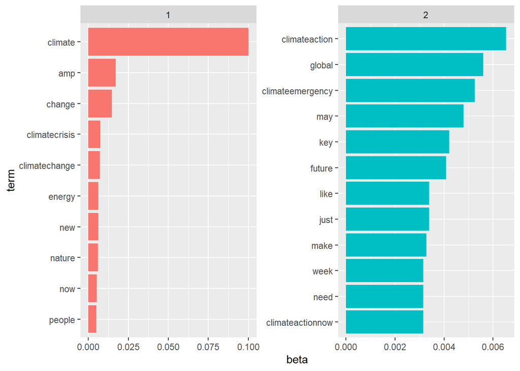

```r
# set parameters for Gibbs sampling
# Gibbs is another sampling tool that draws the instance from the distribution of each variable
burning <- 4000
iter <- 2000
thin <- 500
seed <- list(1000)
nstart <- 1
best <- TRUE

ldaOut <- LDA(climate_dtm, k = 2, method = "Gibbs", control = list(
  nstart = nstart,
  seed = seed,
  iter = iter,
  thin = thin,
  best = best
))


# use the tidy() to transform ldaOut into a matrix
climate_topics_beta <- tidy(ldaOut, matrix = "beta")

# gamma = document and topics
# beta = term and topics


# visualize the dataset
climate_top_terms <- climate_topics_beta %>%
  group_by(topic) %>%
  top_n(10, beta) %>%
  ungroup() %>%
  arrange(topic, -beta)

climate_top_terms %>%
  mutate(term = reorder(term, beta)) %>%
  ggplot(aes(term, beta, fill = factor(topic))) +
  geom_col(show.legend = FALSE) +
  facet_wrap(~ topic, scales = "free") +
  coord_flip()
```

```r
climate_beta_spread <- climate_topics_beta %>%
  mutate(topic = paste0("topic", topic)) %>%
  spread(topic, beta) %>%
  filter(topic1 > .001 | topic2 > .001) %>%
  mutate(log_ratio = log2(topic2 / topic1))
```

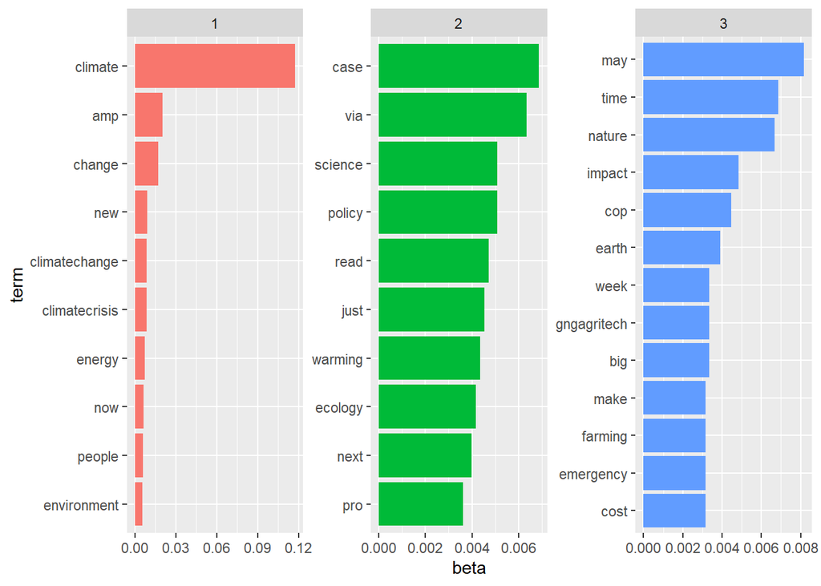

```r
# set parameters for Gibbs sampling
# Gibbs is another sampling tool that draws the instance from the distribution of each variable
burning <- 4000
iter <- 2000
thin <- 500
seed <- list(1000)
nstart <- 1
best <- TRUE

ldaOut <- LDA(climate_dtm, k = 3, method = "Gibbs", control = list(
  nstart = nstart,
  seed = seed,
  iter = iter,
  thin = thin,
  best = best
))


# use the tidy() to transform ldaOut into a matrix
climate_topics_beta <- tidy(ldaOut, matrix = "beta")

# gamma = document and topics
# beta = term and topics


# visualize the dataset
climate_top_terms <- climate_topics_beta %>%
  group_by(topic) %>%
  top_n(10, beta) %>%
  ungroup() %>%
  arrange(topic, -beta)

climate_top_terms %>%
  mutate(term = reorder(term, beta)) %>%
  ggplot(aes(term, beta, fill = factor(topic))) +
  geom_col(show.legend = FALSE) +
  facet_wrap(~ topic, scales = "free") +
  coord_flip()
```

```r
climate_beta_spread <- climate_topics_beta %>%
  mutate(topic = paste0("topic", topic)) %>%
  spread(topic, beta) %>%
  filter(topic1 > .001 | topic2 > .001) %>%
  mutate(log_ratio = log2(topic2 / topic1))
```

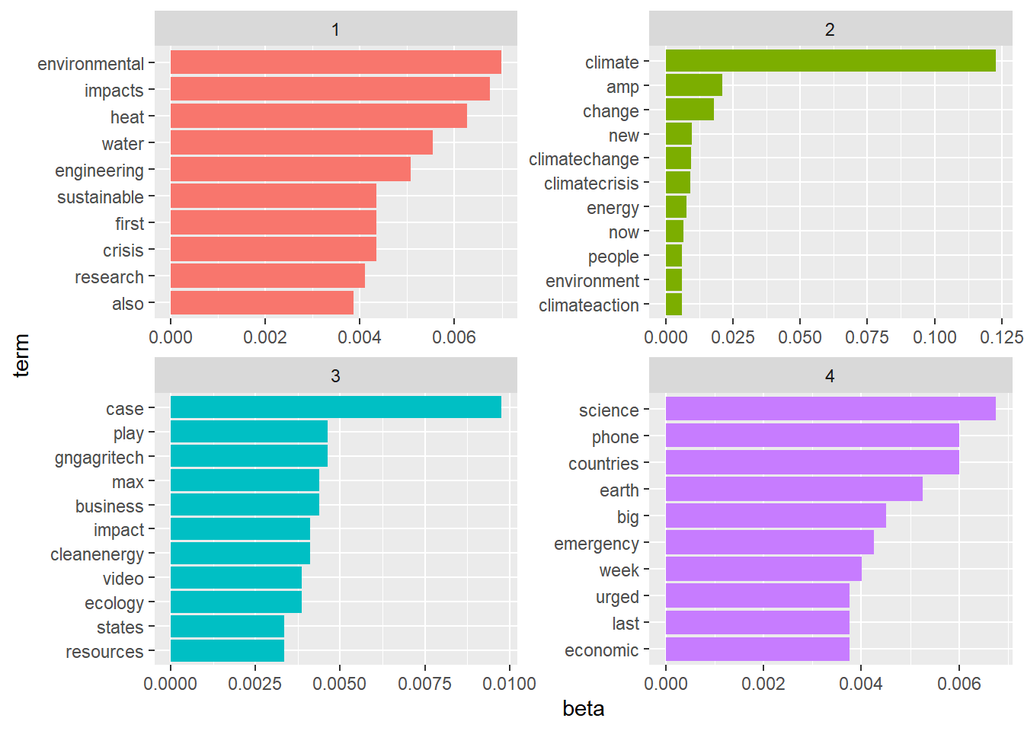

```r
# set parameters for Gibbs sampling
# Gibbs is another sampling tool that draws the instance from the distribution of each variable
burning <- 4000
iter <- 2000
thin <- 500
seed <- list(1000)
nstart <- 1
best <- TRUE

ldaOut <- LDA(climate_dtm, k = 4, method = "Gibbs", control = list(
  nstart = nstart,
  seed = seed,
  iter = iter,
  thin = thin,
  best = best
))


# use the tidy() to transform ldaOut into a matrix
climate_topics_beta <- tidy(ldaOut, matrix = "beta")

# gamma = document and topics
# beta = term and topics


# visualize the dataset
climate_top_terms <- climate_topics_beta %>%
  group_by(topic) %>%
  top_n(10, beta) %>%
  ungroup() %>%
  arrange(topic, -beta)

climate_top_terms %>%
  mutate(term = reorder(term, beta)) %>%
  ggplot(aes(term, beta, fill = factor(topic))) +
  geom_col(show.legend = FALSE) +
  facet_wrap(~ topic, scales = "free") +
  coord_flip()
```

```r
climate_beta_spread <- climate_topics_beta %>%
  mutate(topic = paste0("topic", topic)) %>%
  spread(topic, beta) %>%
  filter(topic1 > .001 | topic2 > .001) %>%
  mutate(log_ratio = log2(topic2 / topic1))
```

## 1.3 Visualise the top 10 words from each topic to brainstorm on possible topics that they cover.

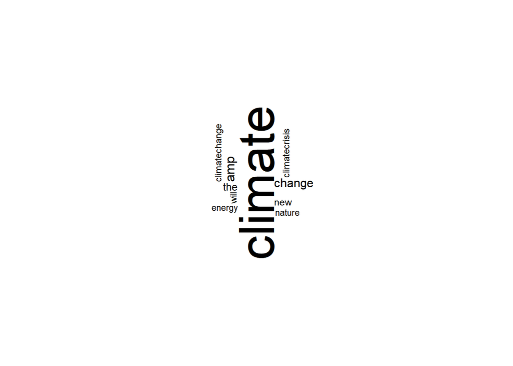

```r
library(tm)
library(wordcloud)
# Create the word cloud
wordcloud(climate_data$text,
          random.order = FALSE,
          rot.per = 0.3,
          scale = c(4,.5),
          max.words = 10,
          font.main = 1,
          cex.main = 1.5)
```

```r
wordcloud
```

[output not shown]

[output cut: 84 more lines]

[output not shown]

## 1.4 Write 2-3 sentences comparing LDA models you generated with different number of topics. Explain which model you think best covers your data.

As shown from the above plot, by changing the number of k() also known as **‘topics’**, this adds new plots to the visualization. For example, by choosing the topic “k=4” we are expecting to view 4 plots when running the script. Regarding the model that best fits my particular data set; k = 3 is what makes more sense regarding the keywords. I found that the more topics you have, the more vague the keywords become; making the model appear as confusing.